# Computo workshop

A hands-on introduction to quarto with a Computo submission

Julien Chiquet

julien.chiquet@inrae.fr

INRAE, MIA-Paris

Pierre Neuvial

Pierre.Neuvial@math.univ-toulouse.fr

CNRS, IMT

Université de Toulouse

Ghislain Durif

ghislain.durif@ens-lyon.fr

CNRS

ENS Lyon, LBMC

Tanguy Lefort

tanguy.lefort@umontpellier.fr

Université de Montpellier, IMAG

CNRS, Inria, LIRMM

François-David Collin

francois-david.collin@umontpellier.fr

CNRS

IMAG

June 5, 2026

## Planning

### Morning session

- ⏰ 9h-10h: Introduction to Computo and Quarto
- ☕ 10h-10h30: Coffee break/Discussion
- 🧑‍💻 10h30-12h00: Hands-on with a toy example

### Afternoon session

- 📝 13h30-15h00: Follow-up with personal article submission process

## Learning objectives

- 🎯 Understand the benefits of reproducible research
- 📄 Learn how to create a quarto document
- 📝 Learn how to include code, data, and narrative text in a quarto document
- 📤 Learn how to submit a quarto document to Computo
- 🧭 How to navigate the Computo submission process (optional)

# Short introduction to Computo and quarto

## Team

Chief Editors Associate Editors

Technical Support Community Management

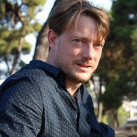

#### Julien Chiquet (chief editor)

Stat. learning for life science  
Paris-Saclay University, INRAE

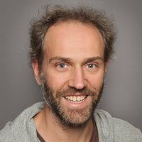

#### Pierre Neuvial (chief editor)

Statistics  
CNRS, IMT Toulouse

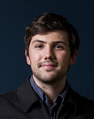

#### Mathieu Carrière

Topological data analysis  
Inria, Sophia Antipolis

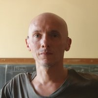

#### Fra.-Dav. Collin

Research Engineer, IA for Microelectronics  
LIRMM, CNRS, Montpellier

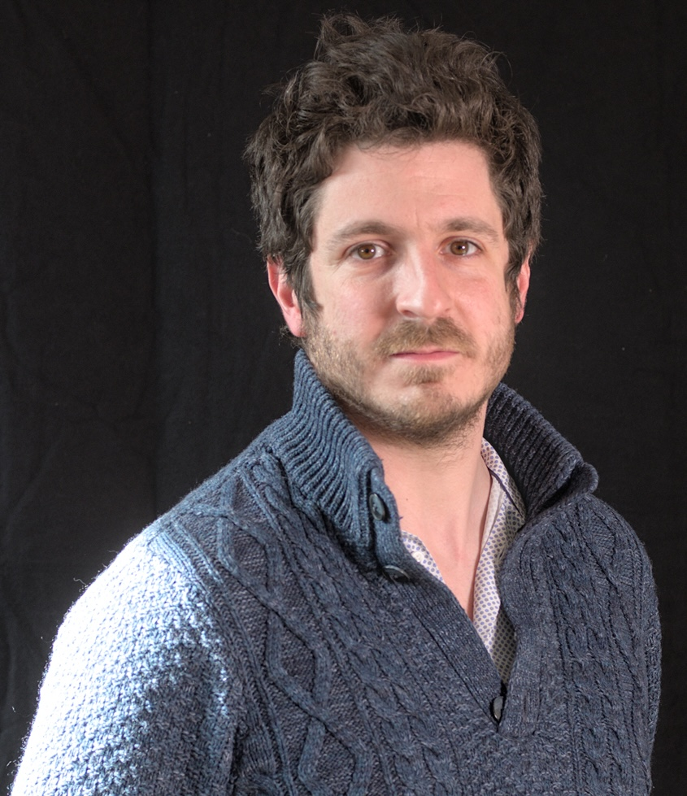

#### Aymeric Stamm

Research Engineer, Statistics  
LMJL Nantes, CNRS

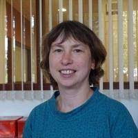

#### Marie-Pierre Étienne

Statistical methods for ecology  
ENSAI CREST, Rennes

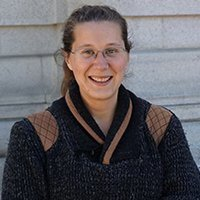

#### Nelle Varoquaux

ML and causal inference for genomics  
CNRS, Grenoble Alpes

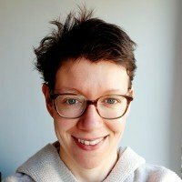

#### Chloé Azencott

ML for therapeutic research  
Mines ParisTech

## What is reproducible research?

Fundamentally, it provides three things:

Tools to reproduce the results (that’s like cooking)

A “recipe” to reproduce the results (still like cooking)

A path to understanding the results and the process that led to them (unlike cooking…<sup>1</sup>)

[^1]: Even so, we may discuss the fact that blindly following recipes will not make you a good cook.

## Pre-Computo era

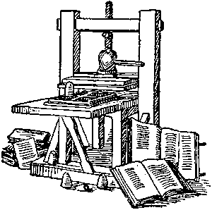

The pdf era and paper submission.

The reproducibility was not a priority:

- 🛠️ Tools had to be bought, installed, and maintained
- 🔒 Data and code were not shared (social engineering)
- ❓ Even methodology details are often missing

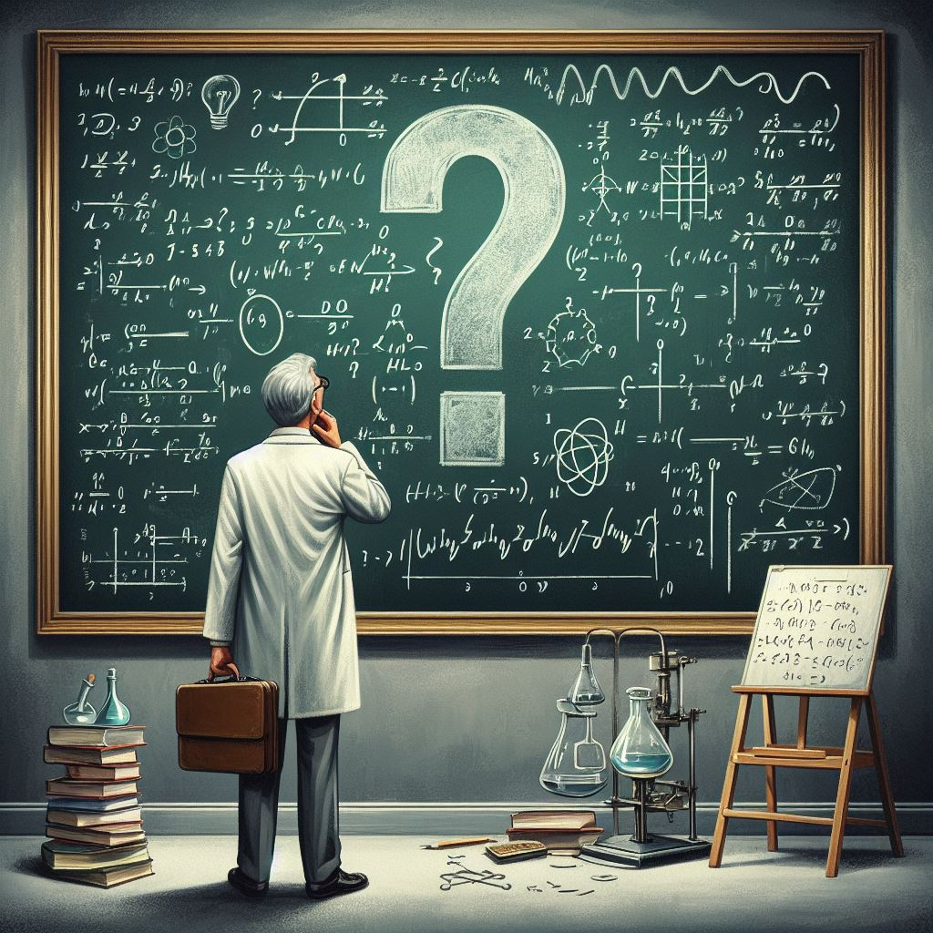

## Pre-Computo era (2)

[figure not shown]

And then in the Machine Learning domain, there was [distill.pub](https://distill.pub/2016/misread-tsne/) [1]

but…

## Pre-Computo era (3)

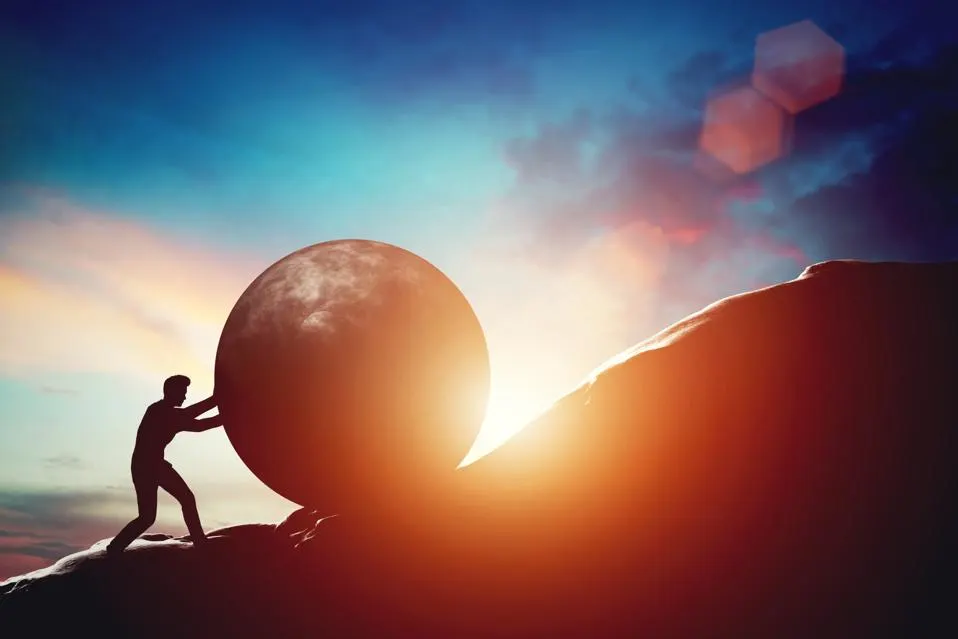

… **engineering was too complex** for the average scientist (a lot of javascript, etc.)

In fact, the distill.pub project was discontinued in 2021 [2]

distill.pub

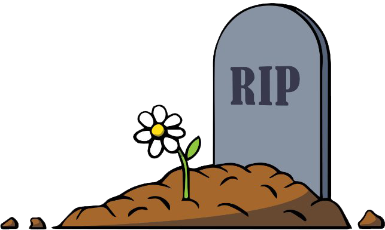

## The Rise of the Pragmatic

distill.pub’s goals were right, but they outpaced themselves in terms of development complexity.

- 🚀 **Computo** is a fresh start with a pragmatic approach
- 🧰 Leverage what the scientific community is already using (Rmarkdown, Jupyter notebooks, etc.)

$\Rightarrow$ *bring the community* to the higher standards

## The Rise of the Pragmatic

distill.pub’s goals were right, but they outpaced themselves in terms of development complexity.

- 🚀 **Computo** is a fresh start with a pragmatic approach
- 🧰 Leverage what the scientific community is already using (Rmarkdown, Jupyter notebooks, etc.)

[figure not shown]

## The Rise of the Pragmatic

distill.pub’s goals were right, but they outpaced themselves in terms of development complexity.

- 🚀 **Computo** is a fresh start with a pragmatic approach
- 🧰 Leverage what the scientific community is already using (Rmarkdown, Jupyter notebooks, etc.)

[figure not shown]

## Origin of Computo (~ 2020s)

[French Statistical Society](https://www.sfds.asso.fr/) appoints a “publication” committee (led by Julien then Pierre) to develop a new journal

**Assessment**

- 😔 Multiplication of “traditional” journals…
- 😔 No valorization of “negative” results
- 😥 No or not enough valorization of source codes and case studies
- 😱 ↘ of publication quality and time dedicated to each article (on author or reviewer sides) [3]
- 😱 Issue with *scientific* reproducibility (analyses, experiments) [4–9]

**Point of view**

- 🔄 Need for renewal regarding scientific research implementation
- 📈 Need for higher standards regarding result publications

⇝ Emergence of “Computo” idea

## Philosophy

**Scientific perimeter**

Promote contribution in **statistics** and **machine learning** that provide insight into which models or methods are more appropriate to address a specific scientific question

**Open access**

- 💎 [“Diamond” open access](https://en.wikipedia.org/wiki/Open_access#Diamond/platinum_OA) (free to publish and free to read, possible to reuse)
- 🅭 🅯 Content published under [CC-BY](https://creativecommons.org/licenses/by/4.0/) license (attribution, share, adapt)
- 📝💬 Reviews and discussions available after acceptance for publication (anonymous reviews)

➡️ In accordance with [Budapest Open Access Initiative (BOAI)](https://www.budapestopenaccessinitiative.org/) and [Plan S](https://www.coalition-s.org/addendum-to-the-coalition-s-guidance-on-the-implementation-of-plan-s/principles-and-implementation/)

**Reproducible**

- 🔢 Numerical (statistical) reproducibility is a necessary condition
- 💾 Source code and data should be available, at least partly executed and fully executable

## Note on reproducible research [10–12]

#### Why reproduce scientific results?

- 💪 To strengthen their credibility
- 🔍 To check for errors (everyone makes errors at some point!!!)
- 🧱 To build new research upon them (science is incremental)

#### Issues?

- 🔄 Reproduce numerical scientific results is often difficult (technology/environment evolution, source code/environment configuration/software partially available or not available)
- ⏳💸 Waste of time and resources to reproduce existing non-reproducible results

#### Reproducible research?

- 👥 For others but also **for your future self**
- ✅ Improve result credibility
- 🚀 Facilitate future research works

## Setup

Official launch at the end of 2021

[figure not shown]

[figure not shown]

### “Economical” model

- 💪 A few tenacious people…
- 🛠️ Free/Open-source community tools (Pandoc, Quarto, Git forge)
- 🏛️ Institutional support (INRAE, INRIA, CNRS, SFdS)

## Functioning

### Writing system

Notebook and literate programming  
text (markdown) + math ($\LaTeX$) + code (Python/R/Julia), references (bib$\TeX$)

### Publication system

Environment management, Compilation, Multi-format publication (pdf, html)  
Continuous integration/Continuous deployment (CI/CD)

### Reviewing system

- 🕵️ Anonymous exchange published after acceptance
- 🧑‍⚖️ Reviewer pool (you can join)
- 🔄 Ongoing migration to *Peer Community In* system
  - Former system: OpenReview
  - New system: https://computo-journal.org/ and https://statml.peercommunityin.org/

#### Solutions/Prototype

Reproducible articles and computations

Automatic editorial reproducibility

Scientific validation

## Note on literate programming

- Literate programming [13]: notebook including text and code
- Markup formatting language: e.g. [`markdown`](https://fr.wikipedia.org/wiki/Markdown)
- Separate content from rendering (≠ [“what you see is what you get”](https://en.wikipedia.org/wiki/WYSIWYG) editors)
- Rendering includes text, code and results (from code computations)

````markdown
---
title: "My article"
---

We compute 1+1:

```{r}
1+1
```
````

## Note on quarto

https://quarto.org

- Generalization of [`Rmarkdown`](https://pkgs.rstudio.com/rmarkdown/)
- Relying on top community tools like universal document converter [`Pandoc`](https://pandoc.org/)
- Developed and supported by RStudio/Posit
- Native support of complex documents (website, articles, books) and multiple languages for computations (R, Python, Julia)
- Management of references, citations, figures, tables, metadata, etc.

## Note on [continuous integration](https://en.wikipedia.org/wiki/Continuous_integration)

- Implementation in git forges (e.g. [github actions](https://github.com/features/actions) or [gitlab CI/CD](https://about.gitlab.com/topics/ci-cd/))
- Triggered by commits
- Automatic tests
- Automatic deployment: package/software publication, website

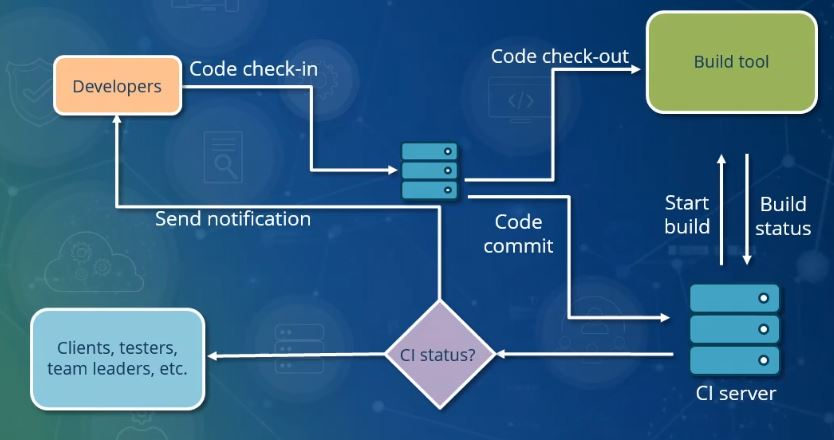

Credit: Pratik89Roy [CC-BY-SA-4.0](https://creativecommons.org/licenses/by-sa/4.0/deed.en) from [Wikimedia](https://en.wikipedia.org/wiki/File:Continuous_Integration.jpg)

## Tools for authors

#### Document model

[`quarto` Computo extension](https://computorg.github.io/computo-quarto-extension/)

[figure not shown]

#### Document template

[Git `template` repository](https://computo-journal.org/site/guidelines-authors.html#sec-templates)

with template notebook document + doc + pre-configured compilation and publication setup

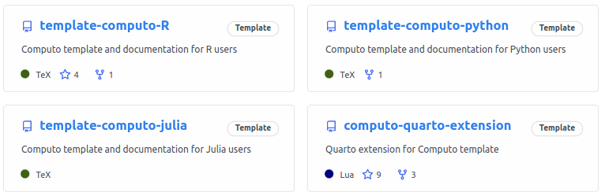

### Locally

- Text editor/IDE (VS Code, Rstudio, NeoVim, etc.)
- Quarto (compilation)
- Julia / R / Python code + computations
- git versioning system

## Author point of view (1/3)

### Step 0: setup a git repository for your article

Startup from a template repository (R, [Python](https://github.com/computorg/template-computo-python), [Julia](https://github.com/computorg/template-computo-julia))

**Tip**

You can host your git repository on [**github**](https://github.com) and soon an any **gitlab** forge<sup>1</sup>.

[figure not shown]

### Step 1: write your article

Let’s go, locally (same spirit as Jupyter/Rmarkdown notebooks)

[^2]: with CI/CD support

## Author point of view (2/3)

### Step 2: configure the environment (dependencies management)

- Example in Python
- Example in R
- Example in Julia

`venv`: use a virtual environment and generate the `requirements.txt` file

```yaml
# requirements.txt
jupyter
matplotlib
numpy
```

`renv`: generate the `renv.lock` file

```r
renv::init()
renv::install("ggplot2")
# or equivalently install.packages("ggplot2")
renv::snapshot()
```

`Pkg`: native `Julia` package manager (with generated `Project.toml` et `Manifest.toml` files)

```julia
add Plots
add IJulia
```

Configuration file versioned and used during CI compilation/publication action

### Step 3: (re)production

A `git push` command will trigger your article compilation (including computations) and publication as a [*github* page](https://pages.github.com)<sup>1</sup>

See the pre-configured `.github/workflows/build.yml` file for the *github* action configuration<sup>2</sup>

[^3]: or as a *gitlab* page when *gitlab* will be supported (soon)
[^4]: and soon the `.gitlab-ci.yml` file for the *gitlab* CI/CD configuration

## Author point of view (3/3)

### Step 4: submit your article

If the CI process succeeds, both HTML and PDF versions are published on the [*github-page*](https://computorg.github.io/template-computo-R/) associated to the repository

#### Submission system (migrating to PCI)

The editorial process is migrating from OpenReview to the *Peer Community In* platform:

- Former platform: https://openreview.net/group?id=Computo
- New platform: https://computo-journal.org/ and https://statml.peercommunityin.org/

Submit:

- your article PDF (scientific content review)
- your git repository (source code and reproducibility review)

[figure not shown]

[figure not shown]

## Editor point of view

After a “traditional” review process, a 3-step procedure:

1. ✅ Acceptance
2. 🛠️ Pre-production
3. 📰 Publication in Computo (with a DOI)

including

- 📥 Copy of the author git repository to https://github.com/computorg/
- 🖋️ Final version formatting
- 📝 Review report publication
- 📚 Registration in the journal bibliographic database
- 🗄️ Copy of the repository to [Software Heritage](https://archive.softwareheritage.org/browse/search/?q=computorg%2Fpublished&with_visit=true&with_content=true) for archiving
- 🌐 Publication of the article on the journal website

[Task-list = github issue](https://github.com/computorg/published-paper-tsne/issues/5)

[figure not shown]

🥲 Fully operational + doi, ISSN

🙂 7 published articles, 3 in pre-production, 6 under review (more details [here](https://computo-journal.org/publications/))

🙂 [French reproducible research network](https://www.recherche-reproductible.fr/)

🤯 Difficult to find reviewers

🤔 Institutional support?

🤔 Changing practices in the scientific community?

## Partnership with PCI StatML

### 🤝 What is PCI StatML?

**PCI StatML** (https://statml.peercommunityin.org/)

- 📝 **Free, community-driven** peer review platform
- 🎯 Scope: statistics and machine learning
- 🤝 Computo is a [*PCI-friendly* journal](https://peercommunityin.org/pci-friendly-journals/)

### 🔄 Current Submission Process

**Direct submission to Computo via OpenReview**

1. Submit via OpenReview (https://openreview.net/group?id=Computo)
2. Peer review + **reproducibility test** (formatting, code, data)
3. Publication in Computo

### 🔮 Future: PCI → Computo Route

Once PCI integration is fully operational:

1. Submit to PCI StatML
2. Peer review (PCI)
3. PCI recommendation
4. **Reproducibility test** Computo (no additional scientific review)
5. Publication in Computo

## Partnership with PCI StatML (continued)

### 📊 Relative Independence

|  | PCI StatML | Computo |
| --- | --- | --- |
| **Role** | Peer review platform | Reproducible journal |
| **Scope** | All Stat/ML domains | **Strong reproducibility focus** |
| **Outlets** | Multiple journals possible | Computo only |

### 🎯 Current Status

- ✅ **OpenReview**: currently active for all Computo submissions
- 🤝 **PCI partnership**: launched, but not yet operational for submissions
- ⚠️ **Migration**: PCI platform integration ongoing (details TBD: submission format, HAL deposition, etc.)
- 🚀 **Future benefit**: accelerated process for PCI-recommended articles (scientific review waived, reproducibility test only)

## Discussion

### About several choices

- **Quarto**: dynamic, agnostic language, [FOSS](https://en.wikipedia.org/wiki/Free_and_open-source_software)<sup>1</sup>, community-based ([`pandoc`](https://pandoc.org/)), Rstudio/Posit support 🚀
- **GitHub**: dynamic, large user community but not institutional and limited computing resources 🌐

### Comparison/inspiration

- [rOpenSci](https://ropensci.org/) / [pyOpenSci](https://www.pyopensci.org/)<sup>2</sup>: software peer review for R/Python packages
  - 📦 **Focus**: package quality, documentation, API design, testing
  - 🤝 **Complementary to Computo**: rOpenSci reviews *software packages*, Computo publishes *scientific articles* with reproducible computations
  - 📰 **Blog post**: [“Computo - A Journal for Transparent and Reproducible Research”](https://ropensci.org/blog/2025/11/06/computo-journal-reproducible-research-statistics-machine-learning/)
- [EpiSciences](https://www.episciences.org/): peer review and publication, but not reproducible by default
- https://rescience.github.io/: “remake” published articles
- https://distill.pub (discontinued): technically more complicated and only ML/AI-oriented
[^5]: “free and open-source”
[^6]: See previous slides for PCI StatML partnership details.

## Perspectives

- 🖥️ Provision of computing resources (to be able to run all computations)
- 🦊 Full *gitlab* support (CI/CD, docker, registry, etc.)
- 🇫🇷 Switch to a french institutional gitlab forge?
- 🛡️ Improve long-term reproducibility stack ([docker](https://www.docker.com/) container, [GUIX](https://guix.gnu.org) fully reproducible environment, or Containers only at the end of the publication process)

### How to help?

- ✍️ By submitting<sup>1</sup> your work!
- 👀 By becoming reviewer<sup>2</sup>
[^7]: https://computo-journal.org/submit/
[^8]: contact us at contact@computo-journal.org

## Regarding the logo

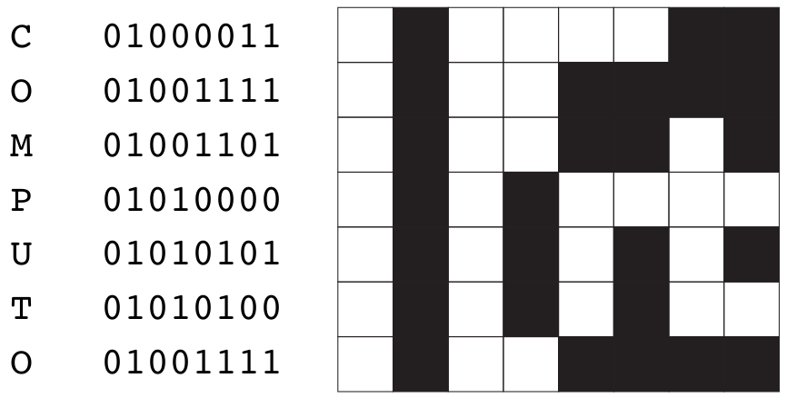

## References

1.

**Olah**, **C** and **Carter**, **S** 2017 Research debt. *Distill*. DOI: https://doi.org/10.23915/distill.00005

2.

**Team**, **E** 2021 Distill hiatus. *Distill*. DOI: https://doi.org/10.23915/distill.00031

3.

**Hanson**, **M A**, **Barreiro**, **P G**, **Crosetto**, **P**, and **Brockington**, **D** 2023 The strain on scientific publishing. DOI: https://doi.org/10.48550/arXiv.2309.15884

4.

**Ioannidis**, **J P A** 2005 Why Most Published Research Findings Are False. *PLoS Medicine*, 2(8): e124. DOI: https://doi.org/10.1371/journal.pmed.0020124

5.

**Steen**, **R G** 2011 Retractions in the scientific literature: Is the incidence of research fraud increasing? *Journal of Medical Ethics*, 37(4): 249–253. DOI: https://doi.org/10.1136/jme.2010.040923

6.

**Allison**, **D B**, **Brown**, **A W**, **George**, **B J**, and **Kaiser**, **K A** 2016 Reproducibility: A tragedy of errors. *Nature*, 530(7588): 27–29. DOI: https://doi.org/10.1038/530027a

7.

**Bastian**, **H** 2016 Reproducibility Crisis Timeline: Milestones in Tackling Research Reliability. URL https://absolutelymaybe.plos.org/2016/12/05/reproducibility-crisis-timeline-milestones-in-tackling-research-reliability/. [Online; accessed 22-March-2023]

8.

**Whitfield**, **J** 2021 Replication Crisis. *London Review of Books*, 43(19). URL https://www.lrb.co.uk/the-paper/v43/n19/john-whitfield/replication-crisis. [Online; accessed 22-March-2023]

9.

**Hernández**, **J A** and **Colom**, **M** 2023 Repeatability, Reproducibility, Replicability, Reusability (4R) in Journals’ Policies and Software/Data Management in Scientific Publications: A Survey, Discussion, and Perspectives. URL https://hal.science/hal-04322522. [Online; accessed 4-January-2024]

10.

**Desquilbet**, **L L**, **Granger**, **S**, **Hejblum**, **B**, **Legrand**, **A**, **Pernot**, **P**, **Rougier**, **N P**, **Castro Guerra**, **E** **de**, **Courbin-Coulaud**, **M**, **Duvaux**, **L**, **Gravier**, **P**, **Le Campion**, **G**, **Roux**, **S**, and **Santos**, **F** 2019 *Vers une recherche reproductible*. Unité régionale de formation à l’information scientifique et technique de Bordeaux. URL https://hal.science/hal-02144142

11.

**Hejblum**, **B P**, **Kunzmann**, **K**, **Lavagnini**, **E**, **Hutchinson**, **A**, **Robertson**, **D**, **Jones**, **S**, and **Eckes-Shephard**, **A** 2020 Realistic and Robust Reproducible Research for Biostatistics. DOI: https://doi.org/10.20944/preprints202006.0002.v1

12.

**The Turing Way Community** 2022 The Turing Way: A handbook for reproducible, ethical and collaborative research. DOI: https://doi.org/10.5281/zenodo.7625728

13.

**Knuth**, **D E** 1984 Literate programming. *The Computer Journal*, 27(2): 97–111.

# Reproducibility considerations

[figure not shown]

Scientific and editorial reproducibility

## Two-fold reproducibility

The global scientific workflow of a reproducible process for a Computo may be split into two types of steps:

**External and Editorial**

## External

**External**

Process to obtain (intermediate) results utside of the notebook environment, for a list of reasons (non-exclusive to each other):

- 🕰️ the process is too long to be conducted in a notebook
- 💾 the data to be processed is too big to be handled directly in the notebook
- 🖥️ it needs a specific environment (e.g. a cluster, with gpus, etc.)
- 🛠️ it needs to involve specific languages (e.g. C, C++, Fortran, etc.) or build tools (e.g. make, cmake, etc.)

## Editorial

**Editorial**

notebook rendering with the results of the external process

**Requirement**

If the notebook contains *everything* to produce the final document

$\Rightarrow$ “Direct reproducibility” in the sense that the notebook is the only thing needed to reproduce the results.

Ultimately, the workflow must end with a direct reproducibility step which concludes the whole process.

## Reproducibility considerations (5)

**Data transfer**

When applicable, the switch from external to editorial reproducibility is done with a “data transfer” step,

data produced by the external process $\Rightarrow$ transferred to the notebook environment.

**Requirement**

Not only the intermediate results are provided, but also **the code to transfer it in the notebook environment.**

There are a variety of software solutions to do so.

## Examples of data transfer solutions

### Intermediate results storage

- 🐍 Python: [`joblib.Memory`](https://joblib.readthedocs.io/en/latest/memory.html), caching mechanism for python functions, save the results of a function call to disk, and load it back later.
- 📦 R : `.RData` file format, can be loaded back in R with the `load()` function.
- 🗃️ If results are small enough, storing them in a text file (e.g. `.csv`, `.tsv`, `.json`, etc.) is also a solution.

### Transfer of the results to the notebook environment

- 📁 (`.joblib` directory or `.Rdata` file) could be committed to the git repository, and directly loaded in the notebook environment.
- ☁️ Alternative, centralize input data (when large enough) and intermediate results on a shared scientific provider (we recommend [Zenodo](https://zenodo.org/) for this purpose), and download them in the notebook environment.

# Workshop

## Quarto

In this workshop, we will learn how to use quarto to create a document that includes code, data, and narrative text. We will also learn how to make the CI (continuous integration) work.

## The main pipeline, step by step

- 🧰 Template installation
- 🧪 computing environment: renv, conda, etc.
- ✍️ Authoring in the qmd
- 🖨️ rendering locally
- 🚀 pushing to github

## Getting started

To get started you will need to clone the mock template for this workshop. The template is available at

https://github.com/computorg/jds2025-workshop-template

## Creating a repo from a template

1. On GitHub.com, navigate to the main page of the repository.
2. Above the file list, click Use this template.
3. Select Create a new repository.

## Cloning the repository

Make a `git clone` of the repository you just templated and open it in your favorite IDE.

## Edit the quarto document

Open `published-paper-tsne.qmd` in your favorite text editor.

Find the code cells marked as “TODO” and modify them in order to have the plots.

Look at the scripts in the `scripts` directory for the plotting code

## Rendering the document

Try to render the document with quarto, it should produce a pdf and an html document.

```bash
quarto render
```

## Making the CI work

ONce you’re happy with the result, it’s time to push the changes to GitHub.

```bash
git add .
git commit -m "My first article"
git push
```

This will trigger the CI workflow, which will run the tests and render the document.

## Checking the CI

You can check the CI status by going to the 🏃‍♂️ **“Actions”** tab of your repository on GitHub. You should see a workflow run triggered by your push 🚦.

## A brief overview of the CI

[figure not shown]

If everything is 🟢 green, you can go to the 📄 **“Pages”** tab of your repository and see the rendered document 🎉.

## Submitting the article

Now you can write a nice mail to the Computo board! 📧🎉

[figure not shown]